# Practical Machilne Learning Course Project

Jose Pablo Escobedo

December 12, 2015

# Background

Using devices such as Jawbone Up, Nike FuelBand, and Fitbit it is now possible to collect a large amount of data about personal activity relatively inexpensively. These type of devices are part of the quantified self movement to find patterns in their behavior, or because they are tech geeks. One thing that people regularly do is quantify how much of a particular activity they do, but they rarely quantify how well they do it. In this, we use data from accelerometers on the belt, forearm, arm, and dumbell of 6 participants. They were asked to perform barbell lifts correctly and incorrectly in 5 different ways. More information is available from the website [here](http://groupware.les.inf.puc-rio.br/har) (see the section on the Weight Lifting Exercise Dataset).

# Data

The training data for this project are available here:

https://d396qusza40orc.cloudfront.net/predmachlearn/pml-training.csv

The test data are available here:

https://d396qusza40orc.cloudfront.net/predmachlearn/pml-testing.csv

The data for this project come from this source: http://groupware.les.inf.puc-rio.br/har.

# Goal

The goal of this project is to predict the manner in which did the exercise.

# Data Analysis / Preprocessing

```r
setwd("/media/jopez/FD26-9473/courses/datascientistspec/repo/practicalmachinelearning");
set.seed(777);
train <- read.csv("pml-training.csv", header=T, sep=",");
dim(train);
```

```
## [1] 19622   160
```

By taking a look at the dataset, we can make the following comments and perform some cleanning/removal of features:

- There is a lack of information about the features. This would greatly help the analysis.
- There seems to be a boolean feature, `new window`, which most of the time is `false`. In this case, several features (67 out of 160) are `NA`. The few times it is `true` (406 out of 19622), and only when this is the case, those 67 features have some values. Since at a first glance this feature does not has a great impact in predicting the type of activity, we can remove the features which have mostly `NA` values.
- Timestamps are useless (in this case) to predict the type of activity. We can remove such features (unless there is information about people’s schedules for doing the activities).
- The first column (`X`) is just an enumeration. We can also remove it.
- We can delete the features which have mostly blank values (filling with the mean or nearest neighbor does not seem useful for cases where there are a lot of missing data).
- The `user name` could not be considered important when predicting the activity. However, since we do not know how the observations were sampled, it is better to consider it.

```r
to_delete <- c("raw_timestamp_part_1",
               "raw_timestamp_part_2",
               "cvtd_timestamp",
                "X");
to_delete <- c(to_delete,colnames(train[colSums(is.na(train)) > dim(train)[1]/2]));
to_delete <- c(to_delete,colnames(train[sapply(train, function(x) (sum(x=="", na.rm = TRUE) > length(x)/2))]))

train <- train[,!names(train) %in% to_delete]
dim(train)
```

```
## [1] 19622    56
```

We now have a clean training set that we can use to train the predictor.

# Training the Predictor

Let us train the predictor using a train, test and validation sets, so we can give some scores and plots to know how good or bad it is classifying the activities, as well as the expected out of the sample error.

Since the dataset is large enough, we can use 70% to train and test the predictor, and the rest to validate it.

```r
library(caret)
library(doMC)
registerDoMC(2);

inBuild    <- createDataPartition(y=train$classe, p=0.70, list=FALSE);
validation <- train[-inBuild,];
buildData  <- train[inBuild,];

inTrain  <- createDataPartition(y=buildData$classe, p=0.70, list=FALSE);
training <- buildData[inTrain,];
testing  <- buildData[-inTrain,];

modFit1 <- train(classe~., data=training, method="rf",
                trControl = trainControl(method = "cv", number=5),
                tuneGrid = data.frame(mtry = 30),
                allowParallel = TRUE);
pred1   <- predict(modFit1, testing);

modFit2 <- train(classe~., data=training, method="pda",
                 allowParallel = TRUE);
pred2   <- predict(modFit2, testing);

modFit3 <- train(classe~., data=training, method="RRF",
                 allowParallel = TRUE);
pred3   <- predict(modFit3, testing);
```

Since we are using different predictors that we are going to combine, we can see how different they predict the activities, as well as their different accuracies.

```r
library(caret)
confusionMatrix(testing$classe, pred1)$overall['Accuracy'];
```

```
##  Accuracy
## 0.9963575
```

```r
confusionMatrix(testing$classe, pred2)$overall['Accuracy'];
```

```
##  Accuracy
## 0.7355512
```

```r
confusionMatrix(testing$classe, pred3)$overall['Accuracy'];
```

```
##  Accuracy
## 0.9997572
```

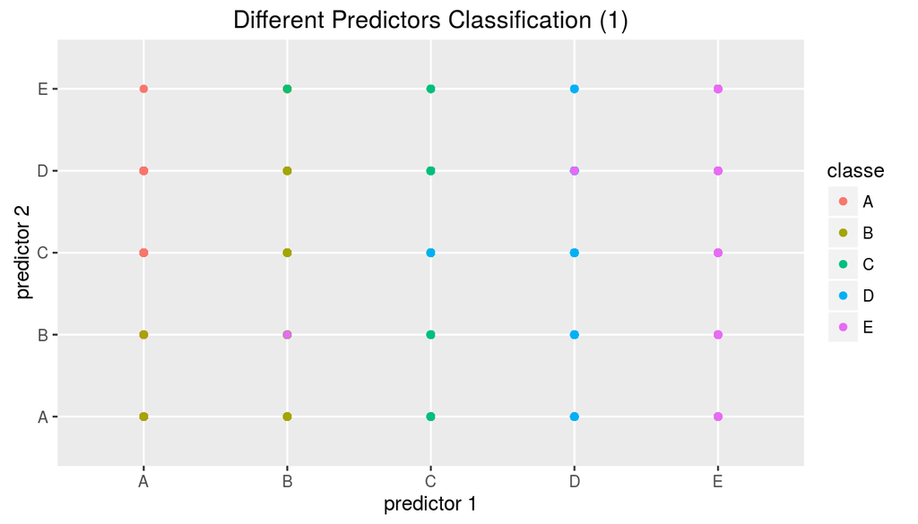

```r
qplot(pred1, pred2, colour = classe, data=testing, xlab="predictor 1", ylab="predictor 2", main="Different Predictors Classification (1)");
```

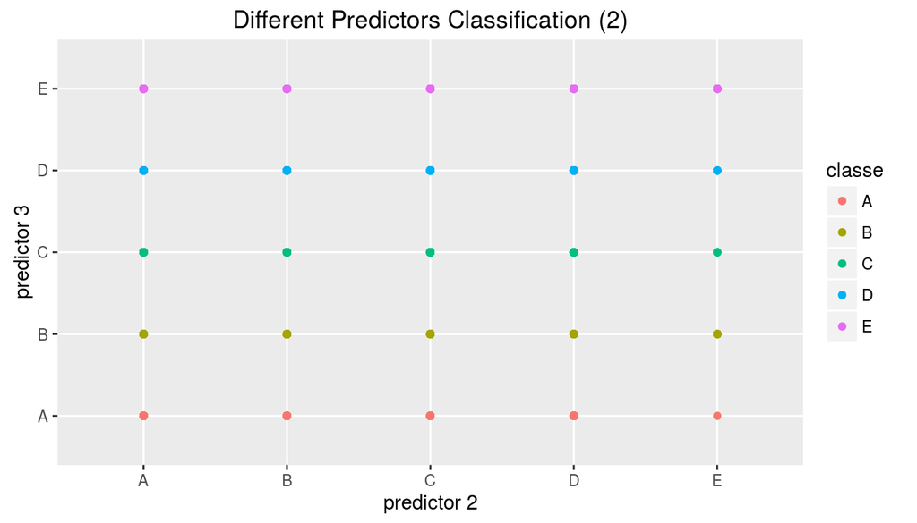

```r
qplot(pred2, pred3, colour = classe, data=testing, xlab="predictor 2", ylab="predictor 3", main="Different Predictors Classification (2)");
```

```r
predTDF <- data.frame(pred1, pred2, classe=testing$classe);
modFit  <- train(classe~., method="rf", data=predTDF,
                trControl = trainControl(method = "cv", number=5),
                allowParallel = TRUE);

predT   <- predict(modFit, predTDF);
confusionMatrix(testing$classe, predT)$overall['Accuracy'];
```

```
##  Accuracy
## 0.9963575
```

# Expected Out of Sample Error

We can use the validation dataset to compute the expected out of sample error of the final predictor.

```r
pred1V  <- predict(modFit1, validation);
pred2V  <- predict(modFit2, validation);
pred3V  <- predict(modFit3, validation);

predVDF  <- data.frame(pred1=pred1V, pred2=pred2V, pred3=pred3V);
combPred <- predict(modFit, predVDF);
```

The next table show how many activities were correctly and incorrectly classified, as well as the *expected out of sample error* (accuracy, specificit, pos pred value, etc. since these measures are based on the validation set).

```r
confusionMatrix(validation$classe, combPred);
```

```
## Confusion Matrix and Statistics
##
##           Reference
## Prediction    A    B    C    D    E
##          A 1674    0    0    0    0
##          B    6 1131    2    0    0
##          C    0    3 1023    0    0
##          D    0    0    7  957    0
##          E    0    2    0    3 1077
##
## Overall Statistics
##
##                Accuracy : 0.9961
##                  95% CI : (0.9941, 0.9975)
##     No Information Rate : 0.2855
##     P-Value [Acc > NIR] : < 2.2e-16
##
##                   Kappa : 0.9951
##  Mcnemar's Test P-Value : NA
##
## Statistics by Class:
##
##                      Class: A Class: B Class: C Class: D Class: E
## Sensitivity            0.9964   0.9956   0.9913   0.9969   1.0000
## Specificity            1.0000   0.9983   0.9994   0.9986   0.9990
## Pos Pred Value         1.0000   0.9930   0.9971   0.9927   0.9954
## Neg Pred Value         0.9986   0.9989   0.9981   0.9994   1.0000
## Prevalence             0.2855   0.1930   0.1754   0.1631   0.1830
## Detection Rate         0.2845   0.1922   0.1738   0.1626   0.1830
## Detection Prevalence   0.2845   0.1935   0.1743   0.1638   0.1839
## Balanced Accuracy      0.9982   0.9970   0.9953   0.9977   0.9995
```

Finally, the tnext figure represents graphically the correct and incorrectly classified activities (`TRUE` means correctly classified, and `FALSE` otherwise).

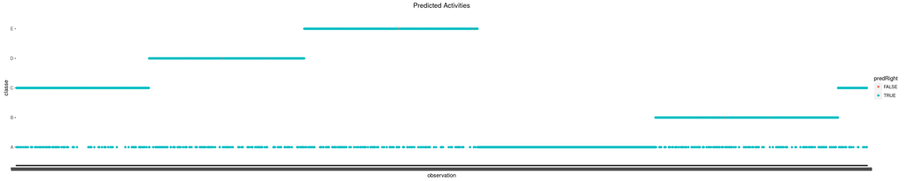

```r
library(ggplot2);
validation$predRight <- combPred == validation$classe;
qplot(rownames(validation), classe, colour=predRight, data=validation,
      xlab = "observation",
      main = "Predicted Activities");
```